# Discrete event Systems simulation - León XIII Clinic - Emergency department

### 7.6.2 Lognormal

```r
fit_adultos_lognormal <- fitdist(tiempos_adultos$dur_servicio, distr = "lnorm", method = "mle")
fit_adultos_lognormal
```

```
## Fitting of the distribution ' lnorm ' by maximum likelihood
## Parameters:
##          estimate Std. Error
## meanlog 10.894904 0.02867717
## sdlog    1.186556 0.02027776
```

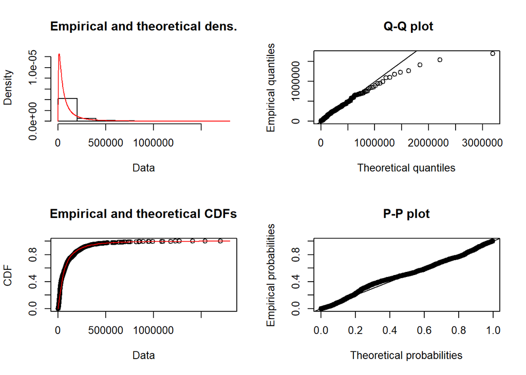

```r
plot(fit_adultos_lognormal)
```

Parece que sí

### 7.6.3 Gamma distribution

Need an scaling factor for the gamma to work, **need to reference this.**

```r
fit_adultos_gamma <- fitdist(tiempos_adultos$dur_servicio/300, distr = "gamma", method = "mle")
fit_adultos_gamma
```

```
## Fitting of the distribution ' gamma ' by maximum likelihood
## Parameters:
##          estimate   Std. Error
## shape 0.847308084 2.081815e-02
## rate  0.002352613 5.795773e-05
```

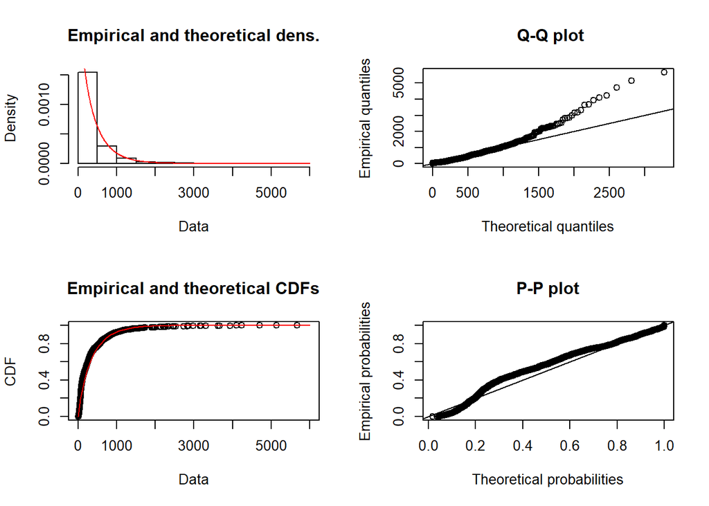

```r
plot(fit_adultos_gamma)
```

No

## 7.7 Tiempo entre llegadas

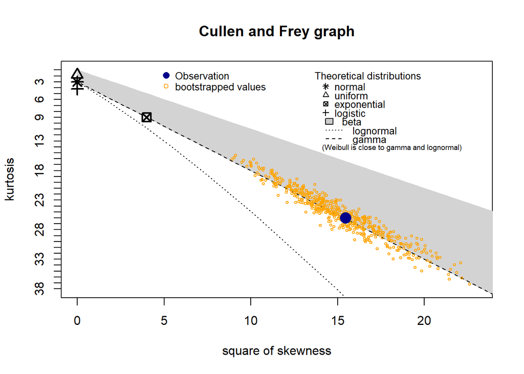

```
## summary statistics
## ------
## min:  1024.626   max:  1700253
## median:  52251.09
## mean:  108025.2
## estimated sd:  156666.2
## estimated skewness:  3.931336
## estimated kurtosis:  26.00525
```

```r
tiempos_adultos <- tiempos %>%
  filter(servicio == "Urgencias",
         servicio_detalle != "Traumas Urgencias",
         servicio_detalle != "Camillas SAI Adultos")

descdist(as.numeric(tiempos_adultos$dur_servicio), boot = 500)
```

### 7.7.1 Exponential

```r
fit_adultos_exp <- fitdist(tiempos_adultos$dur_servicio/250, distr = "exp", method = "mle")
fit_adultos_exp
```

```
## Fitting of the distribution ' exp ' by maximum likelihood
## Parameters:
##         estimate   Std. Error
## rate 0.002314274 4.124049e-05
```

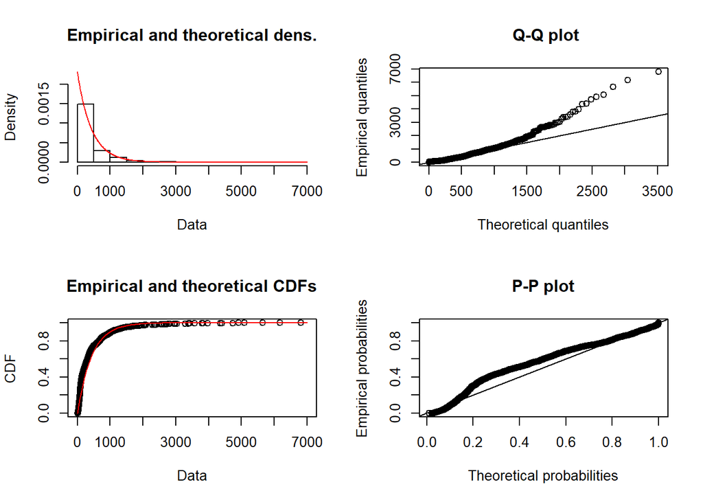

```r
plot(fit_adultos_exp)
```

No.

### 7.7.2 Lognormal

```r
fit_adultos_lognormal <- fitdist(tiempos_adultos$dur_servicio, distr = "lnorm", method = "mle")
fit_adultos_lognormal
```

```
## Fitting of the distribution ' lnorm ' by maximum likelihood
## Parameters:
##          estimate Std. Error
## meanlog 10.894904 0.02867717
## sdlog    1.186556 0.02027776
```

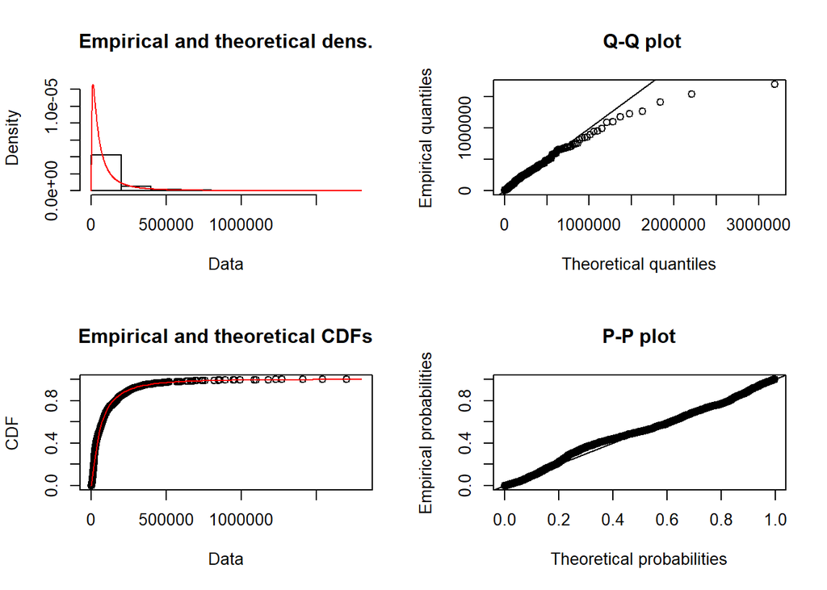

```r
plot(fit_adultos_lognormal)
```

This will be the selected distribution for this variable. May need to consider the kind of triage to correctly estimate a distribution.

### 7.7.3 Gamma distribution

Need an scaling factor for the gamma to work, **need to reference this.**

```r
fit_adultos_gamma <- fitdist(tiempos_adultos$dur_servicio/300, distr = "gamma", method = "mle")
fit_adultos_gamma
```

```
## Fitting of the distribution ' gamma ' by maximum likelihood
## Parameters:
##          estimate   Std. Error
## shape 0.847308084 2.081815e-02
## rate  0.002352613 5.795773e-05
```

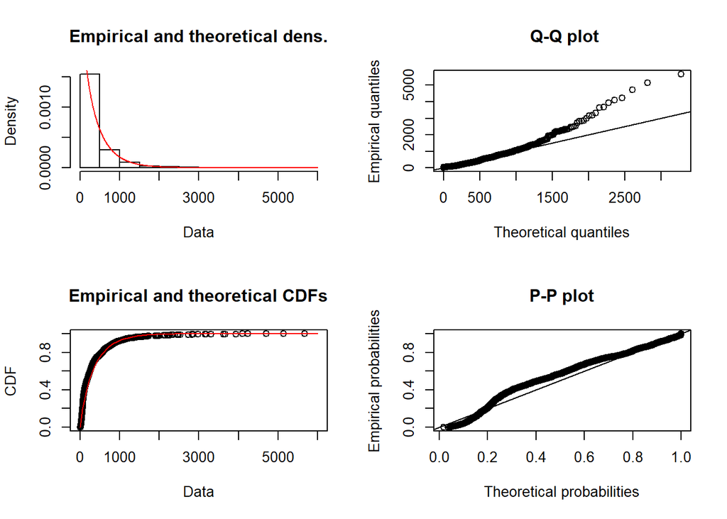

```r
plot(fit_adultos_gamma)
```

No

## 7.8 Tiempo llegadas

### 7.8.1 Weibull distribution

```r
fit_llegadas_weibull <- fitdist(as.numeric(tiempo_llegadas)/250, distr = "weibull")
fit_llegadas_weibull
```

```
## Fitting of the distribution ' weibull ' by maximum likelihood
## Parameters:
##        estimate Std. Error
## shape 0.8925625 0.01050224
## scale 3.7035680 0.06964749
```

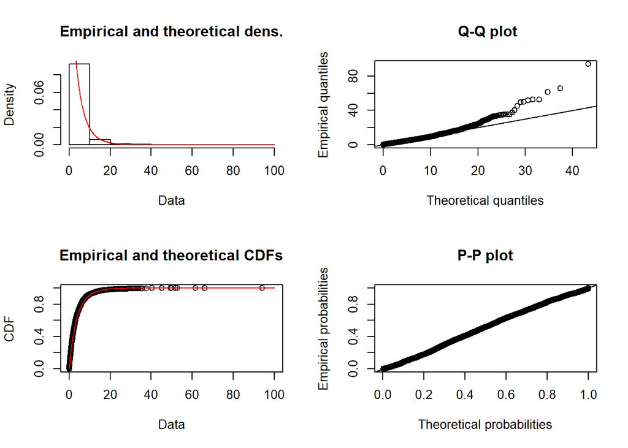

```r
plot(fit_llegadas_weibull)
```

This will be the selected distribution for this variable. May need to consider the kind of triage to correctly estimate a distribution.

### 7.8.2 Gamma distribution

```r
fit_llegadas_gamma <- fitdist(as.numeric(tiempo_llegadas)/200, distr = "gamma", method = "mle")
fit_llegadas_gamma
```

```
## Fitting of the distribution ' gamma ' by maximum likelihood
## Parameters:
##        estimate  Std. Error
## shape 0.8808866 0.017225710
## rate  0.1789306 0.004627332
```

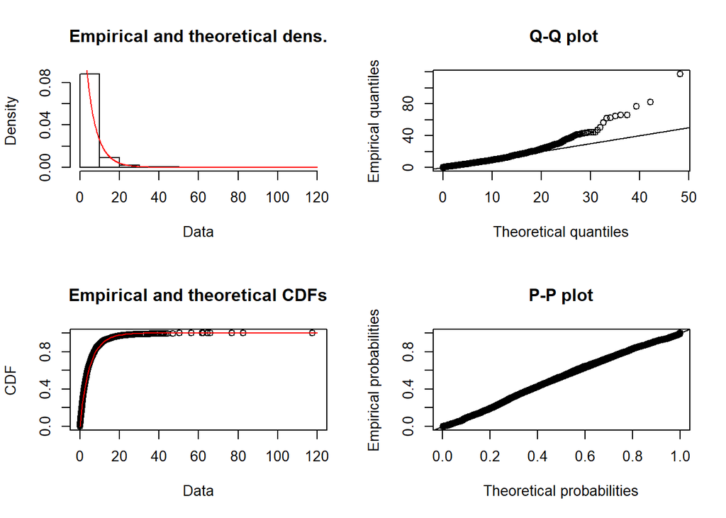

```r
plot(fit_llegadas_gamma)
```

Null hyphotesis could be rejected, need further testing.

### 7.8.3 Lognormal

```r
fit_llegadas_lognormal <- fitdist(as.numeric(tiempo_llegadas)/200, distr = "lnorm", method = "mle")
fit_llegadas_lognormal
```

```
## Fitting of the distribution ' lnorm ' by maximum likelihood
## Parameters:
##          estimate Std. Error
## meanlog 0.9287491 0.02038453
## sdlog   1.2832546 0.01441400
```

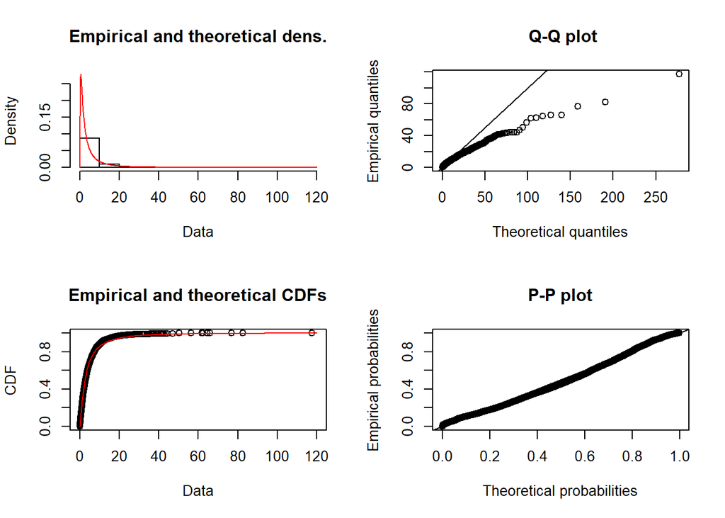

```r
plot(fit_llegadas_lognormal)
```

### 7.8.4 Exponential distribution

```r
fit_llegadas_exp <- fitdist(as.numeric(tiempo_llegadas)/250, distr = "exp")
fit_llegadas_exp
```

```
## Fitting of the distribution ' exp ' by maximum likelihood
## Parameters:
##       estimate  Std. Error
## rate 0.2538874 0.004032946
```

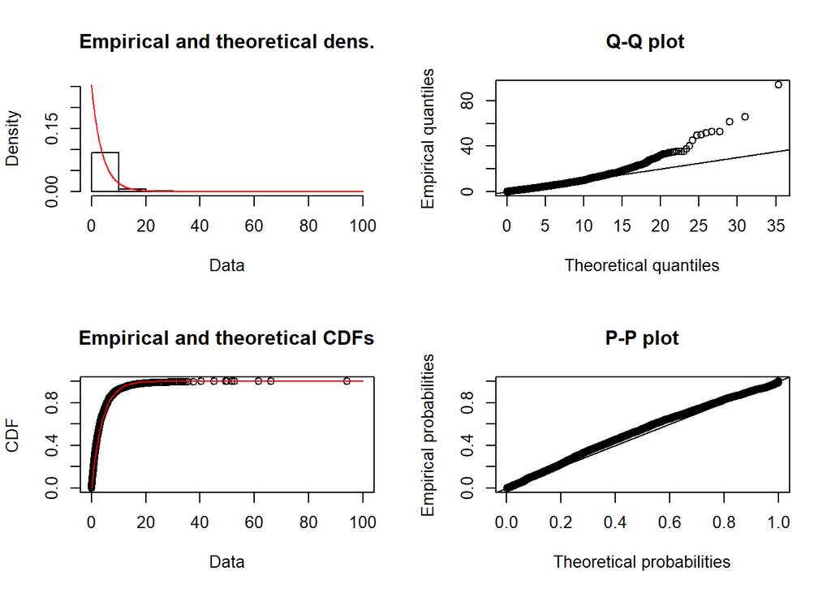

```r
plot(fit_llegadas_exp)
```